# Q2: 131 + 134 Group

Khoi Huynh

2026-10-09

# PSTAT 134 vs. non-PSTAT134

## Loading Data and Defining the ML Areas

```r
library(tidyverse)
library(here)
library(knitr)

background <- read_csv(here('data', 'background-clean.csv'))
interest   <- read_csv(here('data', 'interest-clean.csv'))
```

```r
joined     <- inner_join(background, interest, by = 'response_id')

ml_areas <- c(
  "Analysis or classification of images",
  "Deep learning and neural networks",
  "Data acquisition and engineering",
  "Natural language processing and analysis of text",
  "Predictive modeling, generally",
  "Statistical models and inference, generally"
)
```

We chose these six areas because they were the most closely related to machine learning. Students were able to select from eleven areas of interest, and most of them can be argued to connect to ML in some way. However, this selection focuses primarily on areas involving building, training, or applying predictive models, or preparing the data those models rely on. We recognize that this choice of slection is somewhat subjective and that a different selection could lead to slightly different results.

## PSTAT 134 Enrollment

Something we can look at first is how many students in our sample have taken PSTAT 134 compared to those who have not. This tells us how large each group is before we compare their maching learning interests.

```r
q134 <- joined |>
  mutate(group_134 = if_else(str_detect(courses, fixed('PSTAT 134')),
                             'Took PSTAT 134', 'Did not take PSTAT 134'))

q134 |>
  count(group_134, name = 'n_students') |>
  mutate(proportion = n_students / sum(n_students)) |>
  kable(digits = 3, caption = 'Students by PSTAT 134 enrollment')
```

Students by PSTAT 134 enrollment

| group_134 | n_students | proportion |
| --- | --- | --- |
| Did not take PSTAT 134 | 36 | 0.735 |
| Took PSTAT 134 | 13 | 0.265 |

## Measuring ML Interest for Each Student

Each student could select any number of the eleven interest areas, so we need a single measure of how interested each student is in machine learning. To do this, we can check which of our six ML areas each student selected and count them, giving every student an ML interest score from 0 to 6. This allows us to compare both groups on the scale!

```r
area_long_134 <- q134 |>
  crossing(area = ml_areas) |>
  mutate(selected = str_detect(areas, fixed(area)))

ml_data_134 <- area_long_134 |>
  group_by(response_id, group_134) |>
  summarise(n_ml_areas = sum(selected), .groups = 'drop')

head(ml_data_134)
```

```
## # A tibble: 6 × 3
##   response_id group_134              n_ml_areas
##         <dbl> <chr>                       <int>
## 1        1001 Did not take PSTAT 134          3
## 2        1002 Did not take PSTAT 134          5
## 3        1003 Did not take PSTAT 134          6
## 4        1004 Did not take PSTAT 134          2
## 5        1005 Did not take PSTAT 134          6
## 6        1006 Took PSTAT 134                  3
```

```r
ml_data_134 |>
  count(group_134, n_ml_areas) |>
  pivot_wider(names_from = n_ml_areas, values_from = n, values_fill = 0) |>
  kable(caption = 'Number of students by ML areas selected (out of 6)')
```

Number of students by ML areas selected (out of 6)

| group_134 | 1 | 2 | 3 | 4 | 5 | 6 |
| --- | --- | --- | --- | --- | --- | --- |
| Did not take PSTAT 134 | 1 | 3 | 7 | 12 | 10 | 3 |
| Took PSTAT 134 | 0 | 2 | 3 | 3 | 5 | 0 |

### Summary

```r
ml_data_134 |>
  group_by(group_134) |>
  summarise(n = n(),
            mean_ml_areas = mean(n_ml_areas),
            median_ml_areas = median(n_ml_areas),
            min = min(n_ml_areas),
            max = min(n_ml_areas)) |>
  kable(digits = 2, caption = 'Number of ML-related areas selected, by PSTAT 134 enrollment')
```

Number of ML-related areas selected, by PSTAT 134 enrollment

[output not shown]

## Distribution of ML Interest by Group

While the summary table gives us averages, it does not show how the scores are spread out within each group. A boxplot lets us compare the middle and range of ML interest scores side by side, and adding the individual points shows each student, which is especially helpful since the PSTAT 134 group only has 13 students.

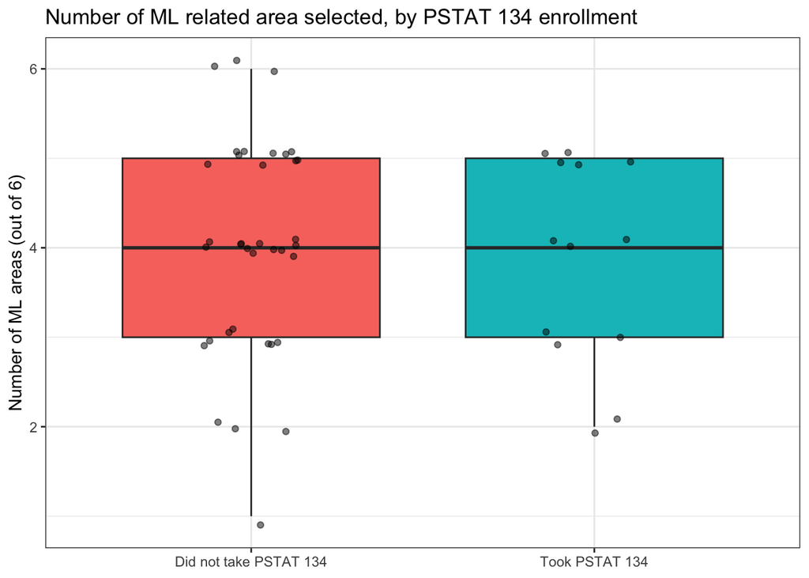

```r
ggplot(ml_data_134, aes(x = group_134, y = n_ml_areas, fill = group_134)) +
  geom_boxplot(outlier.shape = NA) +
  geom_jitter(width = 0.15, height = 0.1, alpha = 0.5) +
  labs(title = "Number of ML related area selected, by PSTAT 134 enrollment",
       x = NULL, y = 'Number of ML areas (out of 6)') +
  theme_bw() +
  theme(legend.position = 'none')
```

The boxplots for both groups look nearly identical: each has a median of 4 ML areas, and the middle 50% of students in both groups selected between 3 and 5 areas. The main difference is in the range, since students who did not take PSTAT 134 spread from 1 to 6 areas, while those who took PSTAT 134 stayed between 2 and 5. Overall, the plot supports our summary table, showing that the two groups have very similar distributions of ML interest.

## ML Interest by Area

So far we have only looked at the total number of ML areas each student selected, which can hide differences in which areas each group prefers. Next, we can break the interest down by individual area and compare the proportion of students in each group who selected it. This shows whether students who took PSTAT 134 lean toward certain ML topics more than others.

```r
area_props_134 <- area_long_134 |>
  group_by(group_134, area) |>
  summarise(n_selected = sum(selected),
            n_students = n(),
            proportion = n_selected / n_students,
            .groups = 'drop')

area_props_134 |>
  select(area, group_134, proportion) |>
  pivot_wider(names_from = group_134, values_from = proportion) |>
  kable(digits = 3, caption = 'Proportion of students selecting each ML area, by PSTAT 134 enrollment')
```

Proportion of students selecting each ML area, by PSTAT 134 enrollment

| area | Did not take PSTAT 134 | Took PSTAT 134 |
| --- | --- | --- |
| Analysis or classification of images | 0.583 | 0.462 |
| Data acquisition and engineering | 0.528 | 0.769 |
| Deep learning and neural networks | 0.778 | 0.846 |
| Natural language processing and analysis of text | 0.528 | 0.462 |
| Predictive modeling, generally | 0.889 | 0.846 |
| Statistical models and inference, generally | 0.694 | 0.462 |

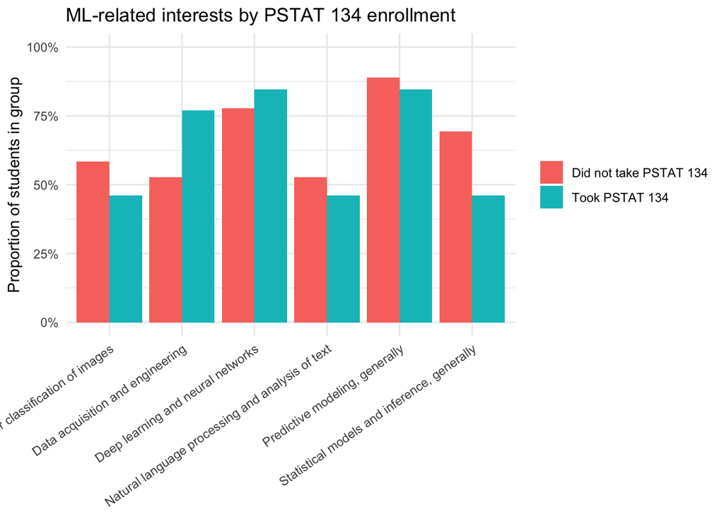

```r
ggplot(area_props_134, aes(x = area, y = proportion, fill = group_134)) +
  geom_col(position = 'dodge') +
  scale_y_continuous(labels = scales::percent, limits = c(0, 1)) +
  labs(title = 'ML-related interests by PSTAT 134 enrollment',
       x = NULL, y = 'Proportion of students in group', fill = NULL) +
  theme_minimal() +
  theme(axis.text.x = element_text(angle = 35, hjust = 1))
```

## 131 + 134 Group (WORK ON LATER)

# filter to students who took both 131 and 134

```r
q2_134 <- joined %>%
  filter(str_detect(courses, fixed('PSTAT 131')),
         str_detect(courses, fixed('PSTAT 134')))
nrow(q2_134)
```

```
## [1] 13
```

# flagging ml areas

```r
q2_134 <- q2_134 |>
  mutate(
    deep_learning = str_detect(areas, fixed('Deep learning and neural networks')),
    stat_inference = str_detect(areas, fixed('Statistical models and inference, generally')),
    images = str_detect(areas, fixed('Analysis or classification of images')),
    nlp = str_detect(areas, fixed('Natural language processing and analysis of text')),
    data_eng = str_detect(areas, fixed('Data acquisition and engineering')),
    predictive = str_detect(areas, fixed('Predictive modeling, generally')),
    ml_score = deep_learning + stat_inference + images + nlp + data_eng + predictive

  )
```

# Results

```r
q2_134 |>
  summarise(n = n(),
            across(c(deep_learning, stat_inference, images, nlp, data_eng, predictive), sum),
            avg_ml_score = mean(ml_score))
```

```
## # A tibble: 1 × 8
##       n deep_learning stat_inference images   nlp data_eng predictive
##   <int>         <int>          <int>  <int> <int>    <int>      <int>
## 1    13            11              6      6     6       10         11
## # ℹ 1 more variable: avg_ml_score <dbl>
```

```r
q2_134 |>
  count(ml_score)
```

```
## # A tibble: 4 × 2
##   ml_score     n
##      <int> <int>
## 1        2     2
## 2        3     3
## 3        4     3
## 4        5     5
```

```r
q2_134 |>
  count(language)
```

```
## # A tibble: 3 × 2
##   language          n
##   <chr>         <int>
## 1 No preference     4
## 2 Python            8
## 3 R                 1
```

# Plot

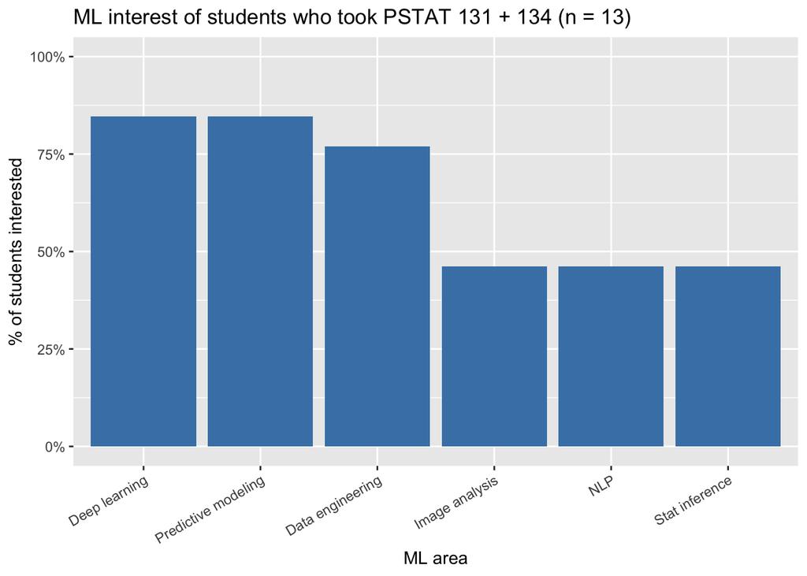

```r
q2_134 |>
  summarise(`Deep learning` = mean(deep_learning),
            `Stat inference` = mean(stat_inference),
            `Image analysis` = mean(images),
            `NLP` = mean(nlp),
            `Data engineering` = mean(data_eng),
            `Predictive modeling` = mean(predictive)) %>%
  pivot_longer(everything(), names_to = 'area', values_to = 'pct') |>
  ggplot(aes(x = reorder(area, -pct), y = pct)) +
  geom_col(fill = 'steelblue') +
  scale_y_continuous(labels = scales::percent, limits = c(0, 1)) +
  labs(x = 'ML area', y = '% of students interested',
       title = 'ML interest of students who took PSTAT 131 + 134 (n = 13)') +
  theme(axis.text.x = element_text(angle = 30, hjust = 1))
```